# Consensos médicos: ¿cómo actuar ante la falta de evidencia científica?

LII Curso Anual de Actualización en Anestesiología y Medicina Perioperatoria

Javier Mancilla Galindo

javimangal@gmail.com

Institute for Risk Assessment Sciences, Utrecht University, Utrecht, Países Bajos

22 de agosto de 2026

# Sobre mí

## Sobre mí

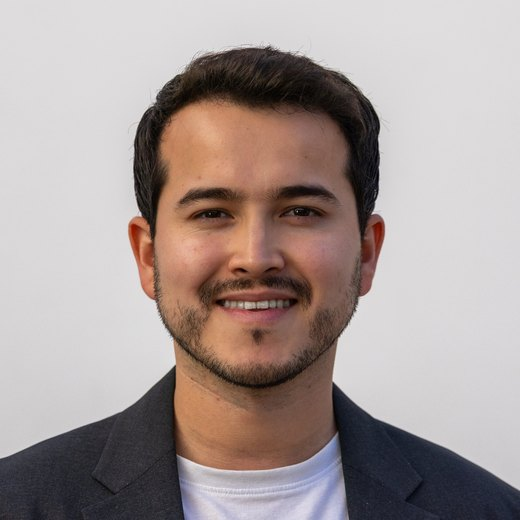

[Perfil institucional](https://research-portal.uu.nl/en/persons/javier-mancilla-galindo/)

[figure not shown]

- Médico Cirujano, Facultad de Medicina UNAM.
- Maestro en Epidemiología, Universidad de Utrecht, Países Bajos.
- Investigador en el Institute for Risk Assessment Sciences, Universidad de Utrecht.
- **Experto en metodología** del Consenso Mexicano de Ventilación Mecánica Perioperatoria del COMEXANE.
- Autor o coautor de 59 trabajos publicados (2019–2026): **26 artículos originales**, **7 cartas y comentarios**, **6 conjuntos de datos abiertos**, y otros 20 trabajos.

## Contenidos

- **Qué es un consenso médico** y en qué se distingue de una guía
- **Elaboración:** el panel, la votación y el reporte
- **Estructurar la incertidumbre:** cuatro clases, cuatro remedios
- **Qué lugar ocupan** en la investigación futura

Los ejemplos vienen del **Consenso Mexicano de Ventilación Mecánica Perioperatoria**, del Colegio Mexicano de Anestesiología (COMEXANE), A.C.

[figure not shown]

doi.org/10.5281/zenodo.21830476

# Qué es un consenso médico

## De dónde nace un consenso

[figure not shown]

[Rosenfeld, et al. (2015)](https://doi.org/10.1177/0194599815601394)<sup>1</sup>

## Un consenso no es una guía de práctica clínica

[Rosenfeld, et al. (2015)](https://doi.org/10.1177/0194599815601394); [Arakawa y Bader (2022)](https://doi.org/10.1016/j.sapharm.2021.06.024)<sup>1,2</sup>

|  | **Guía de práctica clínica** | **Consenso médico** |
| --- | --- | --- |
| Objetivo | **Recomendaciones** basadas en la mejor evidencia disponible | **Enunciados** basados en la opinión de expertos, informados por la mejor evidencia disponible |
| Escenario | Evidencia **suficiente** para recomendar decisiones clínicas | Evidencia **insuficiente o no concluyente**; inconsistencia en la práctica |
| Literatura | Búsqueda sistemática, síntesis, evaluación de calidad y de sesgos | Búsqueda sistemática, síntesis y evaluación flexible |
| Métodos | GRADE | Delphi (modificado), grupos nominales, conferencia de consenso, RAND/UCLA |

## Método Delphi

[figure not shown]

Oráculo de Delfos

Respuestas del dios Apolo, invocadas mediante rituales, para la toma de decisiones.

[Marchais-Roubelat y Roubelat (2011)](https://doi.org/10.1016/j.techfore.2011.04.012)<sup>3</sup>

## Cómo se llega al acuerdo

[figure not shown]

[Nasa, et al. (2021)](https://doi.org/10.5662/wjm.v11.i4.116); [Arakawa y Bader (2022)](https://doi.org/10.1016/j.sapharm.2021.06.024)<sup>2,4</sup>

## Lo que un enunciado de consenso **no** es

- Los enunciados **representan opiniones de expertos** sobre el estado actual del conocimiento.
- **No** son recomendaciones de acción clínica obligatoria.
- **No** son una guía de práctica clínica: una guía exige evidencia suficiente y se construye con GRADE.
- **No** constituyen un estándar legal de atención: el médico responsable determina el manejo apropiado para cada paciente.
- Lo que los justifica es la **incertidumbre**: evidencia insuficiente o no concluyente, con inconsistencia en la práctica clínica.<sup>1</sup>
- [Rosenfeld, et al. (2015)](https://doi.org/10.1177/0194599815601394)

## Cómo se hace

[figure not shown]

[Rosenfeld, et al. (2015)](https://doi.org/10.1177/0194599815601394); [Gattrell, et al. (2024)](https://doi.org/10.1371/journal.pmed.1004326)<sup>1,5</sup>

## Cronograma

[figure not shown]

Intervalos orientativos; la duración de un buen consenso la juzga quien lo organiza

## ¿Quién es un experto?

Aspectos a declarar

- **Criterios de inclusión**, escritos antes de convocar
- **Cuántos panelistas** y por qué ese número
- **Quién los eligió** y cómo
- **Conflictos de interés** y cómo se gestionaron

Características deseables

- **Práctica clínica vigente**, no solo trayectoria
- Formación o producción **en el tema**, no en la especialidad entera
- **Diversidad** de centros, regiones y perfiles
- Una **convocatoria abierta**, no una lista de conocidos

## ¿Cuántos expertos?

[figure not shown]

[Škrinjar, et al. (2026)](https://doi.org/10.1016/j.jclinepi.2026.112262); [Manyara, et al. (2024)](https://doi.org/10.1016/j.jclinepi.2024.111485)<sup>9,10</sup>

## Cómo definen el consenso los estudios Delphi publicados

[figure not shown]

[Diamond, et al. (2014)](https://doi.org/10.1016/j.jclinepi.2013.12.002)<sup>11</sup>

## Dos definiciones de consenso

[figure not shown]

[Rosenfeld, et al. (2015)](https://doi.org/10.1177/0194599815601394); [Diamond, et al. (2014)](https://doi.org/10.1016/j.jclinepi.2013.12.002)<sup>1,11</sup>

## Estudios tamizados e incluidos

Consenso Mexicano de Ventilación Mecánica Perioperatoria, ronda 2. Ocho búsquedas independientes, una por pregunta PICO, en PubMed, Embase, LILACS y CENTRAL.

| Pregunta | Identificados | Al cribado | Revisados | No revisados | Relevantes | Incluidos |
| --- | --- | --- | --- | --- | --- | --- |
| 1. PEEP y obesidad | 1285 | 1009 | 61 | 948 | 2 | **0** |
| 2. Modo ventilatorio | 355 | 254 | 47 | 207 | 3 | **3** |
| 3. *Driving pressure* | 238 | 136 | 49 | 87 | 13 | **11** |
| 4. Volumen tidal | 1266 | 915 | 119 | 796 | 10 | **8** |
| 5. Reclutamiento y PEEP | 571 | 350 | 113 | 237 | 7 | **6** |
| 6. Titulación de FiO<sub>2</sub> | 1262 | 1044 | 146 | 898 | 3 | **2** |
| 7. Extubación | 925 | 761 | 50 | 711 | 3 | **2** |
| 8. Alto flujo y apnea | 2427 | 1700 | 103 | 1597 | 7 | **6** |
| **Total** | **8329** | **6169** | **688** | **5481** | **48** | **38** |

## Síntesis de la evidencia

[figure not shown]

[Gattrell, et al. (2024)](https://doi.org/10.1371/journal.pmed.1004326), ítem M8<sup>5</sup>

Un consenso **no elimina la incertidumbre**. La delimita: dice hasta dónde llega la evidencia y qué haría falta investigar para que llegue.

# Incertidumbre

## Los consensos médicos permiten estructurar la incertidumbre

- Decir «falta evidencia» no es suficiente.
- Lo útil es saber **de qué clase** es esa falta, porque cada una se atiende de una manera distinta.
- Los enunciados del consenso sirven aquí como material: cada uno dejó documentada **una clase distinta** de incertidumbre.

## Cuatro clases de incertidumbre

[figure not shown]

Clasificación propia, no validada, a partir de observaciones del Consenso Mexicano de Ventilación Mecánica Perioperatoria

## 1. Cuando no se encuentran estudios en la búsqueda

«En pacientes adultos con índice de masa corporal >40 kg/m<sup>2</sup> bajo cirugía abdominal (laparoscópica o abierta) y anestesia general con ventilación mecánica, la programación inicial de PEEP alta (ej. >10 cmH<sub>2</sub>O) puede reducir las complicaciones pulmonares postoperatorias en comparación con una PEEP fija baja (ej. 5-10 cmH<sub>2</sub>O) **sin utilizar maniobras de reclutamiento**.»

- Cuatro bases de datos, 1285 registros: **ningún estudio** evaluó esa comparación.
- Los ensayos en obesidad aplicaron la PEEP alta **siempre con** maniobras de reclutamiento;<sup>12,13</sup> el fundamento fisiológico es sólido y **nadie lo discutió**.<sup>14–16</sup>
- **Sin consenso: media 5.50**, RIC de 5, diez respuestas atípicas.
- [Bluth, et al. (2019)](https://doi.org/10.1001/jama.2019.7505) · [Choi, et al. (2023)](https://doi.org/10.1002/oby.23675) · [Pelosi, et al. (1998)](https://doi.org/10.1097/00000539-199809000-00031) · [Behazin, et al. (2010)](https://doi.org/10.1152/japplphysiol.91356.2008) · [Lagier, et al. (2022)](https://doi.org/10.1097/ALN.0000000000004009)

«La ausencia de evidencia no es evidencia de ausencia.»<sup>17</sup>

[Altman DG, Bland JM. *BMJ*. 1995;311(7003):485](https://doi.org/10.1136/bmj.311.7003.485)

## 2. Cuando hay estudios y no coinciden

[figure not shown]

Enunciado 2 del consenso. Estimaciones publicadas de [Liu, et al. (2026)](https://doi.org/10.1038/s41598-026-55547-0) y [Bagchi, et al. (2017)](https://doi.org/10.1111/anae.14039); la de [Li, et al. (2024)](https://doi.org/10.1016/j.accpm.2024.101423) se calculó a partir de los conteos de los dos brazos comparables<sup>18–20</sup>

## 3. Cuando la evidencia viene de otro país

- De los 407 ensayos que sustentan las guías de síndrome coronario agudo, **el 73.2% reclutó en Europa** y el 52.6% en Norteamérica; el resto de las regiones queda muy por debajo.<sup>21</sup>
- El debate sobre la PEEP en obesidad, que es el enunciado 1, es **latinoamericano**: se discute en español y en revistas de la región.<sup>22–24</sup>
- La única evidencia original de la región es un **ensayo brasileño pequeño**, con desenlace radiográfico.<sup>25</sup>
- [Mas-Lladó, et al. (2023)](https://doi.org/10.1093/ehjqcco/qcad007) · [Guerrero Gutiérrez, et al. (2024a)](https://doi.org/10.25237/revchilanestv53n4-15) · [González y Saldaña (2024)](https://doi.org/10.25237/revchilanestv53n5-03) · [Guerrero Gutiérrez, et al. (2024b)](https://doi.org/10.25237/revchilanestv53n6-02) · [Baltieri, et al. (2014)](https://doi.org/10.1590/S0102-6720201400S100007)

## 3. Cuando la evidencia viene de otro tipo de pacientes

«En pacientes adultos bajo cirugía abdominal mayor electiva, la preoxigenación con cánulas nasales de alto flujo durante la inducción e intubación **puede prolongar** el tiempo de apnea segura en comparación con la oxigenoterapia convencional.»

- Las calificaciones más bajas se justificaron por **validez externa**: los estudios se hicieron en cirugía bariátrica, obesidad mórbida o adultos mayores.
- El panel **reformuló el enunciado** para una tercera ronda: población restringida a pacientes **de alto riesgo**.
- Sin consenso: media de 7.33 a 7.08, RIC de 2.75 a 3.50.

## 4. Heterogeneidad en la definición de alto riesgo

| Grupo señalado | Panelistas |
| --- | --- |
| Obesidad (IMC >30 o >40; cirugía bariátrica) | **10** |
| Enfermedad pulmonar crónica | **7** |
| Apnea obstructiva del sueño | **5** |
| Enfermedad cardiovascular | 4 |
| Hipertensión pulmonar | 3 |
| Paciente crítico, sepsis o inestabilidad | 3 |
| Vía aérea difícil | 3 |
| Cáncer | 2 |
| Edad avanzada o fragilidad | 2 |

| Grupo señalado | Panelistas |
| --- | --- |
| Hipoxemia o insuficiencia respiratoria | 2 |
| Anemia | 1 |
| Capacidad funcional <4 MET | 1 |
| Comorbilidad metabólica, renal o hepática | 1 |
| Deterioro cognitivo o depresión | 1 |
| Embarazo | 1 |
| Enfermedad neuromuscular | 1 |
| Estado funcional ASA III-IV | 1 |
| Uso crónico de esteroides | 1 |

Tercera ronda del Consenso Mexicano de Ventilación Mecánica Perioperatoria, pregunta abierta sobre qué grupos deben considerarse de alto riesgo. Respondieron los 13 panelistas; cada uno cuenta una sola vez por categoría y una respuesta puede corresponder a varias. Categorías abreviadas.

# Conclusiones

## Conclusiones

- Un consenso médico **no sustituye** a los ensayos ni a las revisiones sistemáticas: se ocupa de la incertidumbre que estos dejan abierta.
- **No elimina la incertidumbre: la estructura.** Dice hasta dónde llega la evidencia, dónde se acaba y qué haría falta para extenderla.
- Un enunciado sin acuerdo **no es un fracaso**: genera preguntas de investigación prioritarias.
- Leer los comentarios de los expertos separa **la incertidumbre verdadera de un enunciado mal redactado**.
- Lo que hace creíble a un consenso es el **rigor metodológico**: quién es experto, cómo se evalúa la evidencia, cómo se define el acuerdo y la transparencia del proceso.

## Agradecimientos

- Al **Colegio Mexicano de Anestesiología (COMEXANE), A.C.** por la invitación a esta conferencia magistral.
- Al **comité directivo** del Consenso Mexicano de Ventilación Mecánica Perioperatoria.
- Al **comité científico asesor** y al **panel de expertos votantes**, cuyo desacuerdo documentado es la mitad más útil de esta presentación.
- Al **equipo de búsqueda y síntesis** de la evidencia.

[figure not shown]

El consenso completo y su material suplementario: doi.org/10.5281/zenodo.21830476

## Referencias

1.

Rosenfeld RM, Nnacheta LC, Corrigan MD. Clinical Consensus Statement Development Manual. *Otolaryngology–Head and Neck Surgery*. 2015;153(2 Suppl):S1-S14. doi:10.1177/0194599815601394

2.

Arakawa N, Bader LR. Consensus development methods: Considerations for national and global frameworks and policy development. *Research in Social and Administrative Pharmacy*. 2022;18(1):2222-2229. doi:10.1016/j.sapharm.2021.06.024

3.

Marchais-Roubelat A, Roubelat F. The Delphi method as a ritual: Inquiring the Delphic Oracle. *Technological Forecasting and Social Change*. 2011;78(9):1491-1499. doi:10.1016/j.techfore.2011.04.012

4.

Nasa P, Jain R, Juneja D. Delphi methodology in healthcare research: How to decide its appropriateness. *World Journal of Methodology*. 2021;11(4):116-129. doi:10.5662/wjm.v11.i4.116

5.

Gattrell WT, Logullo P, Zuuren EJ van, et al. ACCORD (ACcurate COnsensus Reporting Document): A reporting guideline for consensus methods in biomedicine developed via a modified Delphi. *PLoS Medicine*. 2024;21(1):e1004326. doi:10.1371/journal.pmed.1004326

6.

Rethlefsen ML, Kirtley S, Waffenschmidt S, et al. PRISMA-S: an extension to the PRISMA Statement for Reporting Literature Searches in Systematic Reviews. *Systematic Reviews*. 2021;10(1):39. doi:10.1186/s13643-020-01542-z

## Referencias (cont.)

7.

Hair K, Bahor Z, Macleod M, Liao J, Sena ES. The Automated Systematic Search Deduplicator (ASySD): a rapid, open-source, interoperable tool to remove duplicate citations in biomedical systematic reviews. *BMC Biology*. 2023;21(1):189. doi:10.1186/s12915-023-01686-z

8.

De Bruin J, Lombaers P, Kaandorp C, et al. ASReview LAB v.2: Open-source text screening with multiple agents and a crowd of experts. *Patterns*. 2025;6(7):101318. doi:10.1016/j.patter.2025.101318

9.

Škrinjar I, Vučić K, Puljak L. Sample size and consensus methods used in Delphi studies are heterogeneous: meta-research study. *Journal of Clinical Epidemiology*. 2026;195:112262. doi:10.1016/j.jclinepi.2026.112262

10.

Manyara AM, Purvis A, Ciani O, Collins GS, Taylor RS. Sample size in multistakeholder Delphi surveys: at what minimum sample size do replicability of results stabilize? *Journal of Clinical Epidemiology*. 2024;174:111485. doi:10.1016/j.jclinepi.2024.111485

11.

Diamond IR, Grant RC, Feldman BM, et al. Defining consensus: a systematic review recommends methodologic criteria for reporting of Delphi studies. *Journal of Clinical Epidemiology*. 2014;67(4):401-409. doi:10.1016/j.jclinepi.2013.12.002

12.

Bluth T, Serpa Neto A, Schultz MJ, et al. Effect of Intraoperative High Positive End-Expiratory Pressure (PEEP) With Recruitment Maneuvers vs Low PEEP on Postoperative Pulmonary Complications in Obese Patients: a Randomized Clinical Trial. *JAMA*. 2019;321(23):2292-2305. doi:10.1001/jama.2019.7505

## Referencias (cont.)

13.

Choi JY, Al-Saedy MA, Carlson B. Positive end-expiratory pressure and postoperative complications in patients with obesity: a review and meta-analysis. *Obesity*. 2023;31(4):955-964. doi:10.1002/oby.23675

14.

Pelosi P, Croci M, Ravagnan I, et al. The effects of body mass on lung volumes, respiratory mechanics, and gas exchange during general anesthesia. *Anesthesia and Analgesia*. 1998;87(3):654-660. doi:10.1097/00000539-199809000-00031

15.

Behazin N, Jones SB, Cohen RI, Loring SH. Respiratory restriction and elevated pleural and esophageal pressures in morbid obesity. *Journal of Applied Physiology*. 2010;108(1):212-218. doi:10.1152/japplphysiol.91356.2008

16.

Lagier D, Zeng C, Fernandez-Bustamante A, Vidal Melo MF. Perioperative pulmonary atelectasis: part II. Clinical implications. *Anesthesiology*. 2022;136(1):206-236. doi:10.1097/ALN.0000000000004009

17.

Altman DG, Bland JM. Statistics notes: Absence of evidence is not evidence of absence. *BMJ*. 1995;311(7003):485. doi:10.1136/bmj.311.7003.485

18.

Liu X, Zhao Z, Wu Q, et al. Effects of pressure versus volume controlled ventilation on postoperative pulmonary complications during elderly Trendelenburg laparoscopic surgery. *Scientific Reports*. 2026;16(1). doi:10.1038/s41598-026-55547-0

## Referencias (cont.)

19.

Bagchi A, Rudolph MI, Ng PY, et al. The association of postoperative pulmonary complications in 109,360 patients with pressure-controlled or volume-controlled ventilation. *Anaesthesia*. 2017;72(11):1334-1343. doi:10.1111/anae.14039

20.

Li X, Xu Y, Wang Z, et al. Effect of ventilation mode on postoperative pulmonary complications among intermediate- to high-risk patients undergoing abdominal surgery: A randomized controlled trial. *Anaesthesia Critical Care & Pain Medicine*. 2024;43(6):101423. doi:10.1016/j.accpm.2024.101423

21.

Mas-Lladó C, González-Del-Hoyo M, Siquier-Padilla J, et al. Representativeness in randomised clinical trials supporting acute coronary syndrome guidelines. *European Heart Journal – Quality of Care and Clinical Outcomes*. 2023;9(8):796-805. doi:10.1093/ehjqcco/qcad007

22.

Guerrero Gutiérrez MA, Escarramán Martínez D, Solís Pérez GA, Antolinez-Motta JM, Pérez Nieto OR, Zamarrón López EI. Ventilación mecánica en el paciente con obesidad. *Revista Chilena de Anestesia*. 2024;53(4):399-408. doi:10.25237/revchilanestv53n4-15

23.

González R, Saldaña Á. Ventilación mecánica en paciente con obesidad. *Revista Chilena de Anestesia*. 2024;53(5):450-451. doi:10.25237/revchilanestv53n5-03

24.

Guerrero Gutiérrez MA, Granados Martínez A de J, Escarramán Martínez D, Solís Pérez GA, Antolinez Motta JM, Minutti Palacios M. Respuesta a ventilación mecánica en el paciente con obesidad en el perioperatorio: Evaluación de paradigmas actuales y propuestas para nuevas hipótesis. *Revista Chilena de Anestesia*. 2024;53(6):545-548. doi:10.25237/revchilanestv53n6-02

## Referencias (cont.)

25.

Baltieri L, Santos LA, Rasera-Junior I, Montebelo MIL, Pazzianotto-Forti EM. Use of positive pressure in the bariatric surgery and effects on pulmonary function and prevalence of atelectasis: randomized and blinded clinical trial. *ABCD Arquivos Brasileiros de Cirurgia Digestiva*. 2014;27(Suppl 1):26-30. doi:10.1590/S0102-6720201400S100007